# HW5

William Morris

5/5/2020

# 1

```r
load('HW5_BostonHousing.RDAT')
```

## a.

```r
#a
Boston$chas<-NULL
```

## b.

```r
#b
Boston_sample_covariance<-cov(Boston)
knitr::kable(data.frame(Boston_sample_covariance))
```

|  | crim | zn | indus | nox | rm | age | dis | rad | tax | ptratio | race | lstat | medv |
| --- | --- | --- | --- | --- | --- | --- | --- | --- | --- | --- | --- | --- | --- |
| crim | 73.9865782 | -40.215956 | 23.9923388 | 0.4195939 | -1.3250378 | 85.405322 | -6.8767215 | 46.8477610 | 844.82154 | 5.3993308 | -302.381816 | 27.9861679 | -30.7185080 |
| zn | -40.2159560 | 543.936814 | -85.4126481 | -1.3961482 | 5.1125134 | -373.901548 | 32.6293041 | -63.3486949 | -1236.45374 | -19.7765707 | 373.721402 | -68.7830369 | 77.3151755 |
| indus | 23.9923388 | -85.412648 | 47.0644425 | 0.6070737 | -1.8879566 | 124.513903 | -10.2280975 | 35.5499714 | 833.36029 | 5.6921040 | -223.579756 | 29.5802703 | -30.5208228 |
| nox | 0.4195939 | -1.396148 | 0.6070737 | 0.0134276 | -0.0246034 | 2.385927 | -0.1876958 | 0.6169295 | 13.04629 | 0.0473973 | -4.020570 | 0.4889462 | -0.4554124 |
| rm | -1.3250378 | 5.112513 | -1.8879566 | -0.0246034 | 0.4936709 | -4.751929 | 0.3036634 | -1.2838146 | -34.58345 | -0.5407632 | 8.215006 | -3.0797414 | 4.4934459 |
| age | 85.4053223 | -373.901548 | 124.5139031 | 2.3859272 | -4.7519292 | 792.358399 | -44.3293795 | 111.7708465 | 2402.69012 | 15.9369213 | -702.940328 | 121.0777246 | -97.5890166 |
| dis | -6.8767215 | 32.629304 | -10.2280975 | -0.1876958 | 0.3036634 | -44.329380 | 4.4340151 | -9.0682520 | -189.66459 | -1.0597746 | 56.040356 | -7.4733291 | 4.8402286 |
| rad | 46.8477610 | -63.348695 | 35.5499714 | 0.6169295 | -1.2838146 | 111.770847 | -9.0682520 | 75.8163660 | 1335.75658 | 8.7607162 | -353.276219 | 30.3854424 | -30.5612280 |
| tax | 844.8215381 | -1236.453735 | 833.3602902 | 13.0462855 | -34.5834478 | 2402.690123 | -189.6645917 | 1335.7565765 | 28404.75949 | 168.1531405 | -6797.911215 | 654.7145196 | -726.2557164 |
| ptratio | 5.3993308 | -19.776571 | 5.6921040 | 0.0473973 | -0.5407632 | 15.936921 | -1.0597746 | 8.7607162 | 168.15314 | 4.6869891 | -35.059527 | 5.7827286 | -10.1106571 |
| race | -302.3818163 | 373.721402 | -223.5797555 | -4.0205696 | 8.2150057 | -702.940328 | 56.0403558 | -353.2762194 | -6797.91122 | -35.0595273 | 8334.752263 | -238.6675155 | 279.9898338 |
| lstat | 27.9861679 | -68.783037 | 29.5802703 | 0.4889462 | -3.0797414 | 121.077725 | -7.4733291 | 30.3854424 | 654.71452 | 5.7827286 | -238.667516 | 50.9947595 | -48.4475383 |
| medv | -30.7185080 | 77.315175 | -30.5208228 | -0.4554124 | 4.4934459 | -97.589017 | 4.8402286 | -30.5612280 | -726.25572 | -10.1106571 | 279.989834 | -48.4475383 | 84.5867236 |

```r
#print.data.frame(data.frame(Boston_sample_covariance),
#                 digits = 3)
```

## c.

```r
#c
Boston_eigen<-eigen(Boston_sample_covariance)
Boston_eigenvalues<-Boston_eigen$values
Boston_eigenvectors<-Boston_eigen$vectors
cat("Eigenvalues: ", Boston_eigenvalues)
```

```
## Eigenvalues:  30910.01 6250.814 822.4633 267.2963 77.04076 46.68341 17.06213 13.55804 8.909243 2.720927 1.101998 0.2178827 0.002936813
```

```r
cat("Eigenvectors: ", Boston_eigenvectors)
```

```
## Eigenvectors:  0.0292942 -0.04361195 0.02832855 0.0004496613 -0.001170733 0.08363337 -0.006559279 0.04498659 0.9494105 0.005602991 -0.2911764 0.02296119 -0.02552829 0.006670468 0.001118923 -0.004944462 1.858083e-06 0.0003609076 -0.00569198 0.0003554217 -0.008637282 -0.2926719 -0.002522038 -0.9560…
```

```r
remove(Boston_eigen)
```

## d.

```r
#d
Lambda<-diag(Boston_eigenvalues)
v_lambda_v<-Boston_eigenvectors%*%Lambda%*%t(Boston_eigenvectors)
print(Boston_sample_covariance - v_lambda_v)
```

```
##                  crim            zn         indus           nox
## crim    -1.421085e-14  2.131628e-14  1.421085e-14 -2.220446e-16
## zn       2.131628e-14  2.614797e-12  8.526513e-14 -9.192647e-14
## indus    1.421085e-14  9.947598e-14 -5.186962e-13 -8.626433e-14
## nox     -2.220446e-16 -9.214851e-14 -8.615331e-14 -1.911579e-13
## rm       1.110223e-15 -1.385558e-13  1.110223e-14  1.550496e-14
## age      1.136868e-13  3.979039e-13  7.105427e-14 -6.439294e-14
## dis     -1.332268e-14  0.000000e+00 -5.329071e-15 -1.043610e-14
## rad      4.973799e-14 -1.492140e-13  1.065814e-13 -4.274359e-14
## tax      1.250555e-12 -2.955858e-12  1.023182e-12  1.065814e-13
## ptratio  5.329071e-15 -3.197442e-14  1.154632e-14 -7.244205e-15
## race    -4.547474e-13  2.330580e-12 -2.472689e-12  1.794120e-13
## lstat    3.197442e-14 -1.421085e-13  8.881784e-14 -2.287059e-14
## medv    -2.486900e-14  2.842171e-13 -6.039613e-14  3.325118e-14
##                    rm           age           dis           rad
## crim     1.110223e-15  1.278977e-13 -1.332268e-14  4.973799e-14
## zn      -1.385558e-13  3.979039e-13  0.000000e+00 -1.492140e-13
## indus    1.110223e-14  7.105427e-14 -5.329071e-15  1.136868e-13
## nox      1.550496e-14 -6.439294e-14 -1.043610e-14 -4.274359e-14
## rm       1.798561e-14  1.145750e-13 -3.330669e-15 -4.574119e-14
## age      1.145750e-13 -5.684342e-13 -2.131628e-14  4.973799e-13
## dis     -3.330669e-15 -2.131628e-14  1.776357e-15 -4.085621e-14
## rad     -4.551914e-14  4.973799e-13 -3.907985e-14  2.557954e-13
## tax     -1.065814e-13  6.366463e-12 -5.400125e-13  2.955858e-12
## ptratio -4.440892e-16  3.375078e-14  2.886580e-15  2.842171e-14
## race    -1.243450e-14 -1.591616e-12  9.947598e-14 -2.842171e-13
## lstat   -3.286260e-14  1.563194e-13 -3.907985e-14  1.953993e-13
## medv     5.773160e-14 -1.989520e-13  2.398082e-14 -2.273737e-13
##                   tax       ptratio          race         lstat
## crim     1.250555e-12  5.329071e-15 -4.547474e-13  3.197442e-14
## zn      -2.955858e-12 -3.552714e-14  2.273737e-12 -1.421085e-13
## indus    1.023182e-12  1.154632e-14 -2.444267e-12  8.881784e-14
## nox      1.065814e-13 -7.244205e-15  1.794120e-13 -2.298162e-14
## rm      -1.065814e-13 -4.440892e-16 -1.243450e-14 -3.286260e-14
## age      6.366463e-12  2.664535e-14 -1.477929e-12  1.421085e-13
## dis     -5.400125e-13  2.886580e-15  9.947598e-14 -3.907985e-14
## rad      2.955858e-12  2.842171e-14 -2.842171e-13  1.882938e-13
## tax      5.820766e-11  3.979039e-13 -2.000888e-11  2.160050e-12
## ptratio  3.979039e-13  1.154632e-14 -7.105427e-14  5.329071e-15
## race    -2.182787e-11 -7.815970e-14  1.455192e-11  0.000000e+00
## lstat    2.273737e-12  5.329071e-15 -2.842171e-14  1.492140e-13
## medv    -2.501110e-12 -3.907985e-14  0.000000e+00 -1.563194e-13
##                  medv
## crim    -2.842171e-14
## zn       2.842171e-13
## indus   -6.039613e-14
## nox      3.325118e-14
## rm       5.773160e-14
## age     -1.705303e-13
## dis      2.398082e-14
## rad     -2.273737e-13
## tax     -2.501110e-12
## ptratio -3.907985e-14
## race     0.000000e+00
## lstat   -1.563194e-13
## medv     1.847411e-13
```

```r
remove(Lambda,v_lambda_v)
```

## e.

```r
#e
pca<-princomp(Boston)
```

## f.

```r
#f
Boston_pca_variance<-(pca$sdev)^2
```

## g.

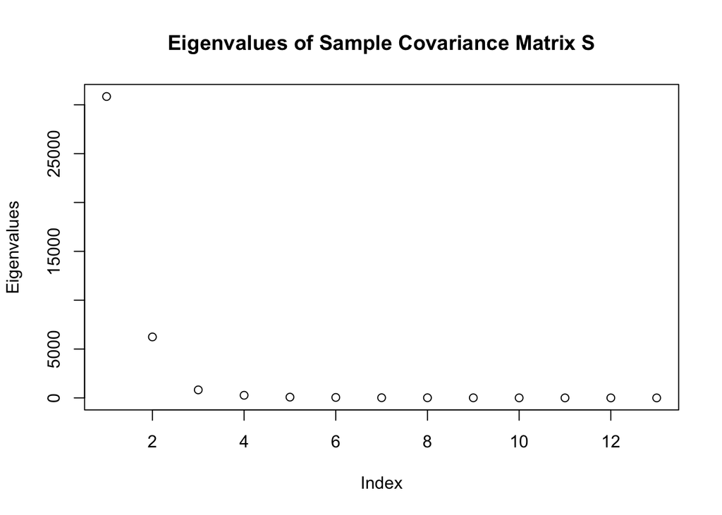

```r
#g
plot(Boston_pca_variance,ylab='Eigenvalues',main='Eigenvalues of Sample Covariance Matrix S')
```

## h.

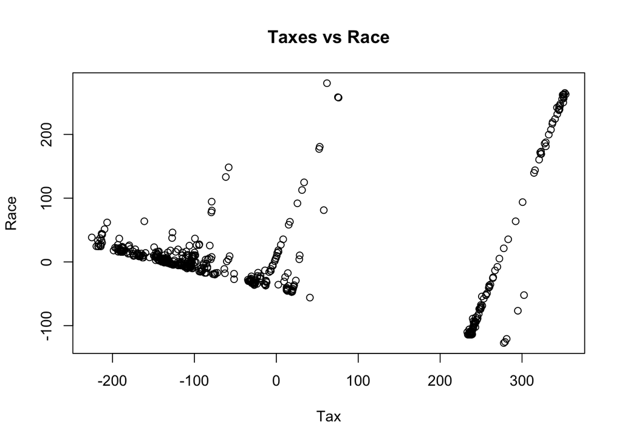

```r
#h
plot(pca$scores[,1],pca$scores[,2],xlab='Tax',ylab='Race',main='Taxes vs Race')
```

I don’t know which version is more current, but the documentation for the Boston housing data on R Studio doesn’t have a “race” component. Instead, it has a variable called “black” which attepmts to give the average number of black people in a house’s neighborhood. That being said, there is definitely a negative correlation between taxes and the race of a neighborhood, with a distinct separation into 2 clusters, implying white and black neighborhoods.

Also, I count 4 places where the data shows a significant positive correlation withing the larger graph. From this, I gather that some neighborhoods have become gentrified while keeping racial diversity. Although, this is not the majority.

## i.

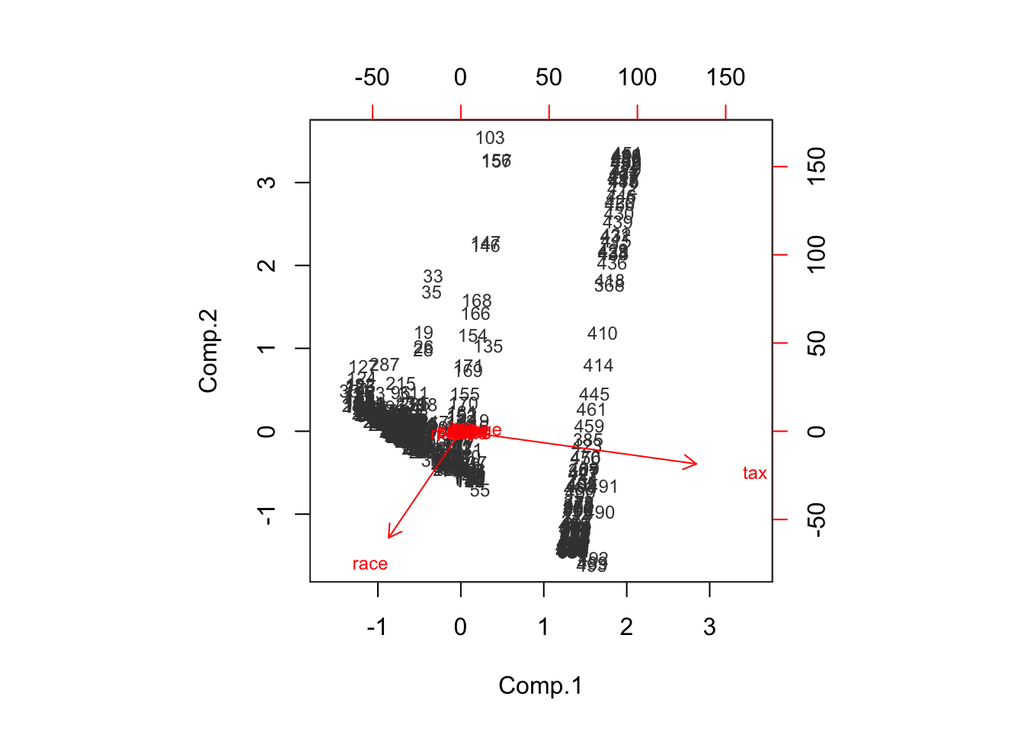

```r
#i
biplot(pca,choices=c(1,2),col=c('gray25','red'),cex=.75,pc.biplot = T)
```

```r
pca.V<-pca$loadings
pca.L <- pca$sdev^2
{
  p1 <- sapply(1:13,function(u) pca.L[u]/sum(pca.L))
  p2 <- sapply(1:13,function(u) sum(pca.L[1:u])/sum(pca.L))
  data.frame(Proportion_of_Total_Variance=p1,Percentage_Explained=p2)
}
```

|  | Proportion_of_Total_Variance | Percentage_Explained |
| --- | --- | --- |
| Comp.1 | 8.045735e-01 | 0.8045735 |
| Comp.2 | 1.627058e-01 | 0.9672794 |
| Comp.3 | 2.140834e-02 | 0.9886877 |
| Comp.4 | 6.957600e-03 | 0.9956453 |
| Comp.5 | 2.005336e-03 | 0.9976507 |
| Comp.6 | 1.215148e-03 | 0.9988658 |
| Comp.7 | 4.441196e-04 | 0.9993099 |
| Comp.8 | 3.529097e-04 | 0.9996628 |
| Comp.9 | 2.319035e-04 | 0.9998947 |
| Comp.10 | 7.082450e-05 | 0.9999656 |

[output cut: 3 more lines]